# Третий этап индивидуального проекта

Основы информационной безопасности

Серёгина Ирина Андреевна

Российский университет дружбы народов, Москва, Россия

06 апреля 2024

## Цель работы

Научиться основным способам тестирования веб приложений

## Задание

Установить и протестировать Hydra

## Теоретическое введение

Hydra используется для подбора или взлома имени пользователя и пароля.

## Теоретическое введение

Основные опции: -R – повторно запустить незавершенную сессию; -S – подключаться с использованием протокола SSL; -s – вручную указать порт подключения к серверу; -l – указать определенный логин пользователя; -L – подключить файл со списком логинов; -p – внести конкретный пароль; -P – использовать пароли из текстового файла; -M – атаковать цели, указанные в списке; -x – активировать генератор паролей; -u – включается проверка одного пароля для всех логинов; -f – закрыть программу, если обнаружена правильная связка «логин-пароль»; -o – сохранить результаты сканирования в указанный файл; -t – принудительно задать количество потоков; -w – указать время, которое проходит между запросами (в секундах); -v – включить режим подробного вывода информации; -V – выводить тестируемые логины и пароли.

## Выполнение лабораторной работы

[figure not shown]

файл с паролем

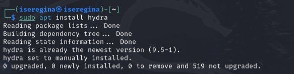

установка Hydra

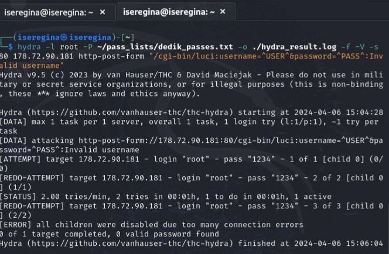

проверка работы Hydra

## Выводы

Я научилась одному из основных способов тестирования веб приложений